# Reuters – Single-label, Multi-class Classification with Text

Scenario 1: One-hot Encoding

Rick Scavetta

## Learning Goals & Functions

### Learning Goals

Text analysis using one-hot encoding

### Functions in this session:

Here we’ll see some basic ways of working with text, using one-hot encoding.

| Function | Description |
| --- | --- |
| `dataset_reuters()` | Import the Reuters Newswire dataset. |
| `dataset_reuters_word_index()` | Reuters dataset word index. |
| `to_categorical()` | Vectorize labels for use with softmax and `categorical_crossentropy` loss function. |

## Part 1: Data Preparation

For multi-class classification, we previously use `sparse_cateogircal_crossentropy`, here we’ll see `categorical_crossentropy`.

### Obtain data

```r
c(c(train_data, train_labels), c(test_data, test_labels)) %<-% dataset_reuters(num_words = 10000)
```

### Examine data:

```r
length(train_data)
```

```
## [1] 8982
```

```r
length(test_data)
```

```
## [1] 2246
```

An example of the data

```r
train_data[[1]]
```

```
##  [1]    1    2    2    8   43   10  447    5   25  207  270    5 3095  111
## [15]   16  369  186   90   67    7   89    5   19  102    6   19  124   15
## [29]   90   67   84   22  482   26    7   48    4   49    8  864   39  209
## [43]  154    6  151    6   83   11   15   22  155   11   15    7   48    9
## [57] 4579 1005  504    6  258    6  272   11   15   22  134   44   11   15
## [71]   16    8  197 1245   90   67   52   29  209   30   32  132    6  109
## [85]   15   17   12
```

Map values back onto the lexicon which is stored as a named list. Each item in the list is an integer vector of length one. This number corresponds to the position in the word count list and the name of the vector is the actual word.

```r
dataset_reuters_word_index() %>%
  unlist() %>%                      # produce a vector
  sort() %>%                        # put them in order
  names() -> word_index             # take the ordered names

# The indices are offset by 3 since 0, 1, and 2 are reserved
# for "padding", "start of sequence", and "unknown"
library(purrr)
train_data[[1]] %>%
  map(~ ifelse(.x >= 3, word_index[.x - 3], "?")) %>%
  as_vector() %>%
  cat()
```

```
## ? ? ? said as a result of its december acquisition of space co it expects earnings per share in 1987 of 1 15 to 1 30 dlrs per share up from 70 cts in 1986 the company said pretax net should rise to nine to 10 mln dlrs from six mln dlrs in 1986 and rental operation revenues to 19 to 22 mln dlrs fr…
```

### Prepare the data:

We’ll use one-hot encoding:

```r
vectorize_sequences <- function(sequences, dimension = 10000) {
  # Create a matrix of 0s
  results <- matrix(0, nrow = length(sequences), ncol = dimension)

  # Populate the matrix with 1s
  for (i in 1:length(sequences))
    results[i, sequences[[i]]] <- 1
  results
}

train_data_vec <- vectorize_sequences(train_data)
test_data_vec <- vectorize_sequences(test_data)
```

Let’s look at the first example from the training set. Recall that these are the index positions of the words

```r
train_example <- sort(unique(train_data[[1]]))
train_example
```

```
##  [1]    1    2    4    5    6    7    8    9   10   11   12   15   16   17
## [15]   19   22   25   26   29   30   32   39   43   44   48   49   52   67
## [29]   83   84   89   90  102  109  111  124  132  134  151  154  155  186
## [43]  197  207  209  258  270  272  369  447  482  504  864 1005 1245 3095
## [57] 4579
```

Now we have a large matrix, where each row is 10000 elements long. Wherever we have a value in the above data set, the matrix has a 1

```r
# Just the first 100 values in the first entry (row)
train_data_vec[1,1:100]
```

```
##   [1] 1 1 0 1 1 1 1 1 1 1 1 1 0 0 1 1 1 0 1 0 0 1 0 0 1 1 0 0 1 1 0 1 0 0 0
##  [36] 0 0 0 1 0 0 0 1 1 0 0 0 1 1 0 0 1 0 0 0 0 0 0 0 0 0 0 0 0 0 0 1 0 0 0
##  [71] 0 0 0 0 0 0 0 0 0 0 0 0 1 1 0 0 0 0 1 1 0 0 0 0 0 0 0 0 0 0
```

In one-hot noding, we only get 1s and 0s. The position of the 1s corresponds to the indices above:

```r
which(as.logical(train_data_vec[1,]))
```

```
##  [1]    1    2    4    5    6    7    8    9   10   11   12   15   16   17
## [15]   19   22   25   26   29   30   32   39   43   44   48   49   52   67
## [29]   83   84   89   90  102  109  111  124  132  134  151  154  155  186
## [43]  197  207  209  258  270  272  369  447  482  504  864 1005 1245 3095
## [57] 4579
```

### Prepare labels:

The `_labels` objects contain the news wire labels. Each newswire can only have one *label* (i.e. “sigle-label”), from a total of 46 possible *classes* (i.e. “multi-class”). The classes are just given numerical values (0 - 45), it doesn’t matter what they are actually called, although that information would be helpful in understanding mis-labeling.

```r
str(train_labels)
```

```
##  int [1:8982] 3 4 3 4 4 4 4 3 3 16 ...
```

Some classes are very common, which we’ll see play out in our confusion matrix below

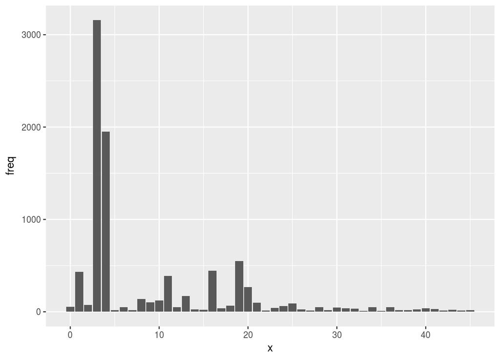

```r
# Note plyr not dplyr here. I'm just using a shortcut
library(ggplot2)
train_labels %>%
  plyr::count() %>%
  ggplot(aes(x, freq)) +
  geom_col()
```

The distribution of the test and training set should be roughly equivalent, so let’s have a look.

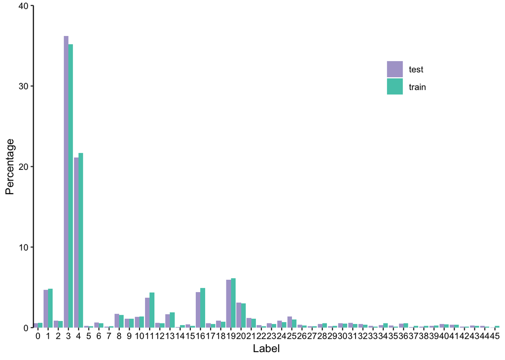

```r
data.frame(x = train_labels) %>%
  group_by(x) %>%
  summarise(train_freq = 100 * n()/length(train_data)) -> train_labels_df

data.frame(x  = test_labels) %>%
  group_by(x) %>%
  summarise(train_freq = 100 * n()/length(test_data)) %>%
  inner_join(train_labels_df, by="x") %>%
  gather(key, value, -x) %>%
  ggplot(aes(x, value, fill = key)) +
  geom_col(position = "dodge") +
  scale_y_continuous("Percentage", limits = c(0,40), expand = c(0,0)) +
  scale_x_continuous("Label", breaks = 0:45, expand = c(0,0)) +
  scale_fill_manual("", labels = c("test","train"), values = c("#AEA5D0", "#54C8B7")) +
  theme_classic() +
  theme(legend.position = c(0.8, 0.8),
        axis.line.x = element_blank(),
        axis.text = element_text(colour = "black"))
```

We make the format match the output we expect to get from softmax so that we can make a direct comparison.

```r
train_labels_vec <- to_categorical(train_labels)
test_labels_vec <- to_categorical(test_labels)
```

```r
str(train_labels_vec)
```

```
##  num [1:8982, 1:46] 0 0 0 0 0 0 0 0 0 0 ...
```

```r
str(test_labels_vec)
```

```
##  num [1:2246, 1:46] 0 0 0 0 0 0 0 0 0 0 ...
```

Notice the similiarity to how we prepared our training data with one-hot encoding, both are sparse matrices. Each row in the training data contains a 1 at the position where that word is present, and in the labels, each row contains a maximum of a single 1, indicating the class.

## Part 2: Define Network

### Define the network

```r
network <- keras_model_sequential() %>%
  layer_dense(units = 64, activation = "relu", input_shape = 10000) %>%
  layer_dense(units = 64, activation = "relu") %>%
  layer_dense(units = 46, activation = "softmax")
```

### View a summary of the network

```r
summary(network)
```

```
## ___________________________________________________________________________
## Layer (type)                     Output Shape                  Param #
## ===========================================================================
## dense_1 (Dense)                  (None, 64)                    640064
## ___________________________________________________________________________
## dense_2 (Dense)                  (None, 64)                    4160
## ___________________________________________________________________________
## dense_3 (Dense)                  (None, 46)                    2990
## ===========================================================================
## Total params: 647,214
## Trainable params: 647,214
## Non-trainable params: 0
## ___________________________________________________________________________
```

### Compile

```r
network %>% compile(
  optimizer = "rmsprop",
  loss = "categorical_crossentropy",
  metrics = "accuracy"
)
```

## Part 3: Validate our approach

Let’s set apart 1,000 samples in our training data to use as a validation set:

```r
index <- 1:1000
val_data_vec <- train_data_vec[index,]
train_data_vec <- train_data_vec[-index,]
val_labels_vec <- train_labels_vec[index,]
train_labels_vec = train_labels_vec[-index,]
```

Now let’s train our network for 20 epochs:

```r
history <- network %>% fit(
  train_data_vec,
  train_labels_vec,
  epochs = 20,
  batch_size = 512,
  validation_data = list(val_data_vec, val_labels_vec)
)
```

Let’s display its loss and accuracy curves:

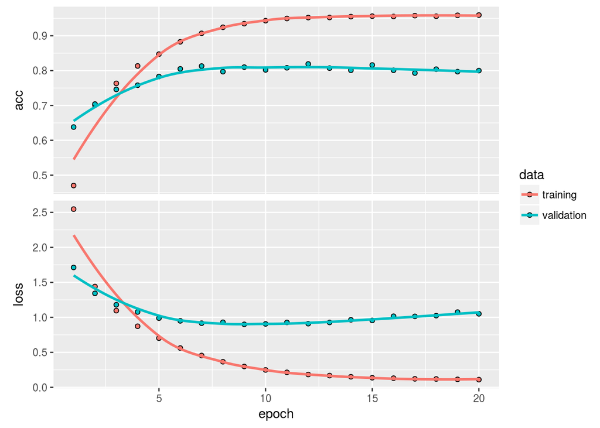

```r
plot(history)
```

The network begins to overfit after nine epochs. Let’s train a new network from scratch for nine epochs and then evaluate it on the test set.

```r
network <- keras_model_sequential() %>%
  layer_dense(units = 64, activation = "relu", input_shape = c(10000)) %>%
  layer_dense(units = 64, activation = "relu") %>%
  layer_dense(units = 46, activation = "softmax")

network %>% compile(
  optimizer = "rmsprop",
  loss = "categorical_crossentropy",
  metrics = c("accuracy")
)
history <- network %>% fit(
  train_data_vec,
  train_labels_vec,
  epochs = 9,
  batch_size = 512,
  validation_data = list(val_data_vec, val_labels_vec)
)
```

## Part 4: Check output

Let’s return to our original model using the vectorized data:

### Metrics

```r
# Recall the original integer data:
test_labels[1]
```

```
## [1] 3
```

```r
# We vectorized it to get 46 values, all zero except 1 where our value is
# This matches the out put from the softmax function.
test_labels_vec[1,]
```

```
##  [1] 0 0 0 1 0 0 0 0 0 0 0 0 0 0 0 0 0 0 0 0 0 0 0 0 0 0 0 0 0 0 0 0 0 0 0
## [36] 0 0 0 0 0 0 0 0 0 0 0
```

```r
metrics <- network %>% evaluate(test_data_vec, test_labels_vec)
```

```r
metrics
```

```
## $loss
## [1] 1.021877
##
## $acc
## [1] 0.777382
```

Our accuracty is 0.777382 and the error rate, i.e. incorrect calling, is 0.222618.

### Predictions

Predict classes will give us the integer values from the test data:

```r
predictions <- network %>% predict_classes(test_data_vec)
predictions[1:10]
```

```
##  [1]  3 10  1 16 13  3  3  3  3  3
```

```r
actual <- unlist(test_labels)
totalmisses <- sum(predictions != actual)
```

This means we have a total of 500 misses.

### Confusion Matrix

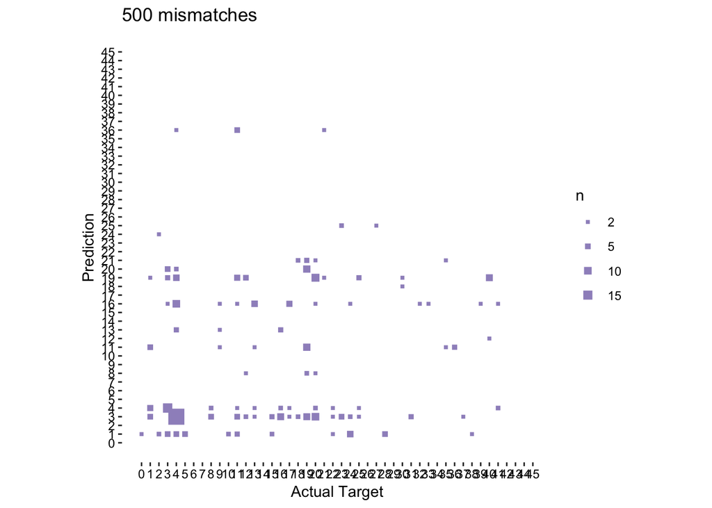